# Lab 4A

```r
library(tidyverse)
library(hexbin)
```

# Plotting with ggplot2

```r
surveys_complete <- read_csv("Results/surveys_complete.csv")
```

```r
ggplot(data=surveys_complete, mapping = aes(x=weight, y=hindfoot_length))+
  geom_point()
```

[output not shown]

```r
surveys_plot<-ggplot(data=surveys_complete, mapping = aes(x=weight, y=hindfoot_length))

surveys_plot+geom_point()
```

[output not shown]

## **Challenge**

Scatter plots can be useful exploratory tools for small datasets. For data sets withlarge numbers of observations, such as the surveys_complete data set, overplottingof points can be a limitation of scatter plots. One strategy for handling such settingsis to use hexagonal binning of observations. The plot space is tessellated intohexagons. Each hexagon is assigned a color based on the number of observationsthat fall within its boundaries. To use hexagonal binning with ggplot2, first install theR package hexbin from CRAN:

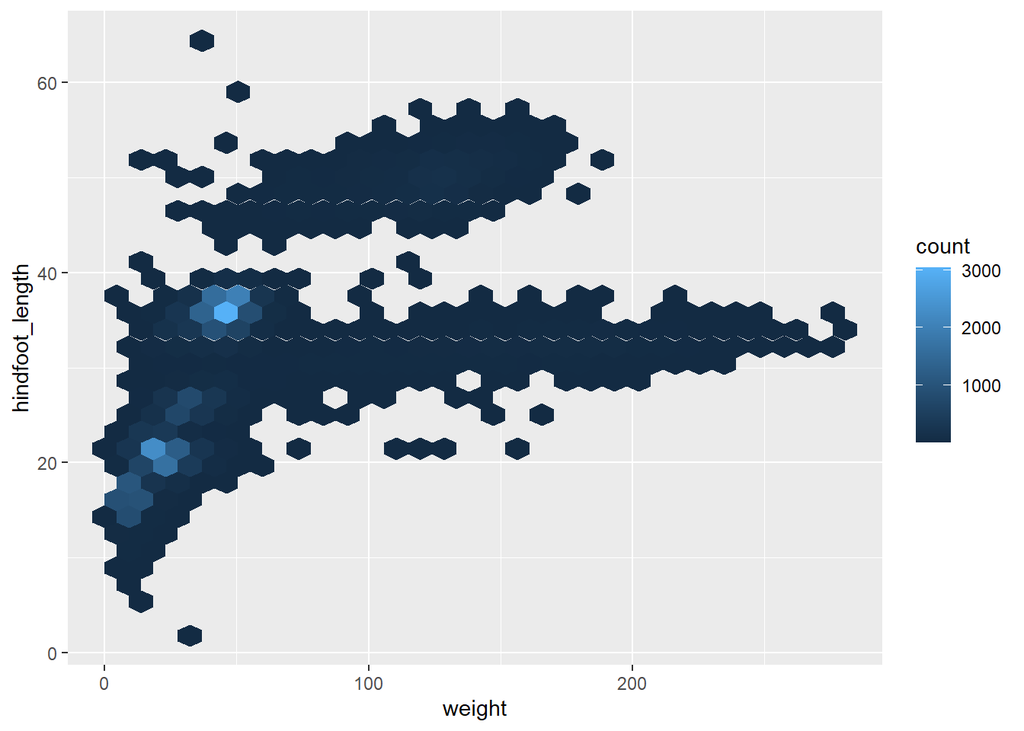

```r
surveys_plot+geom_hex()
```

```
## [1] "Strengths of hexagonal plot- density of data points can be observed. Over plotting issue arised in geo_scatter plots is fixed by hexagonal plotting. \n\nWeaknes of hexagonal plot- individual data points cannot be seen. Hence, the number of data points used to plot cannot be seen."
```

# Building your plots iteratively

```r
ggplot(data =surveys_complete, aes(x = weight,y =hindfoot_length))+
geom_point()
```

[output not shown]

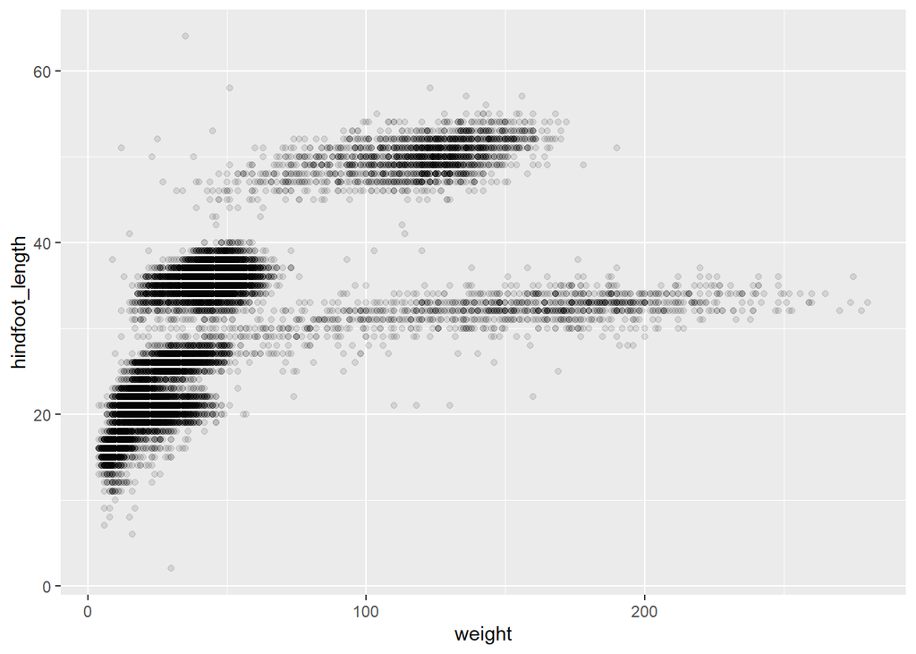

```r
ggplot(data =surveys_complete, aes(x = weight,y =hindfoot_length))+
geom_point(alpha=0.1)
```

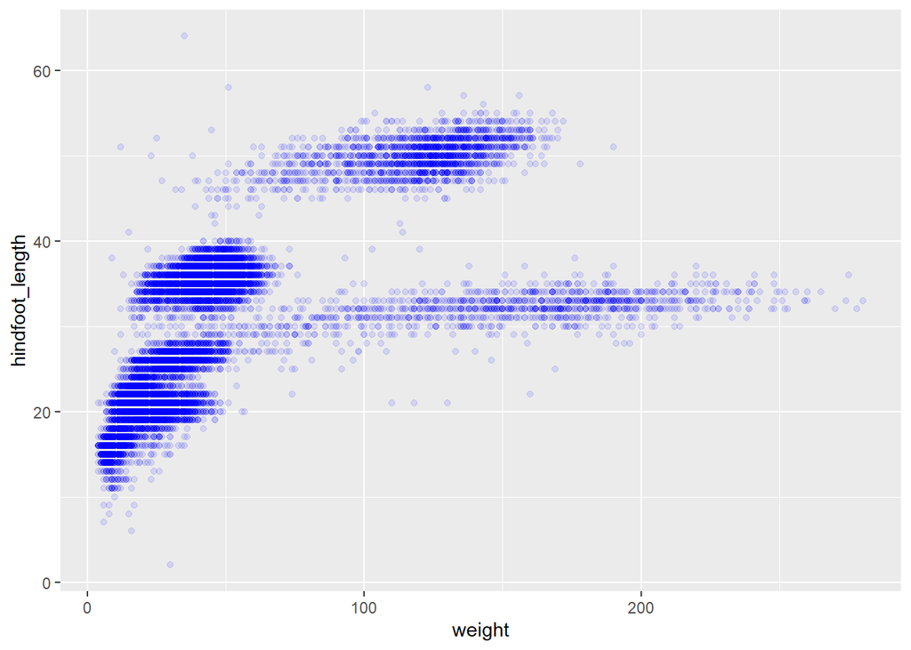

```r
ggplot(data =surveys_complete, aes(x = weight,y =hindfoot_length))+
geom_point(alpha=0.1, color="blue")
```

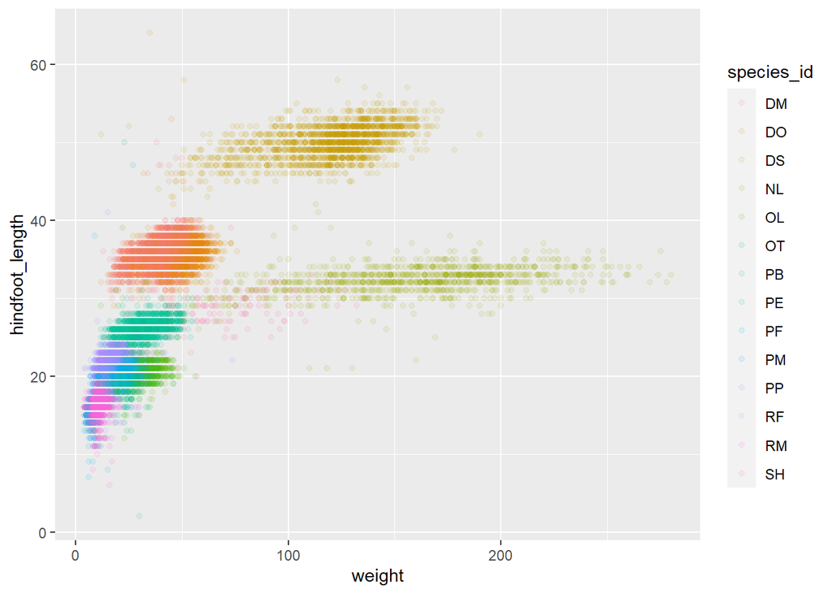

```r
ggplot(data =surveys_complete, aes(x = weight,y =hindfoot_length))+
geom_point(aes(color=species_id), alpha=0.1)
```

## **Challenge**

Use what you just learned to create a scatter plot of weight over species_id with the plot types showing in different colors. Is this a good way to show this type of data?

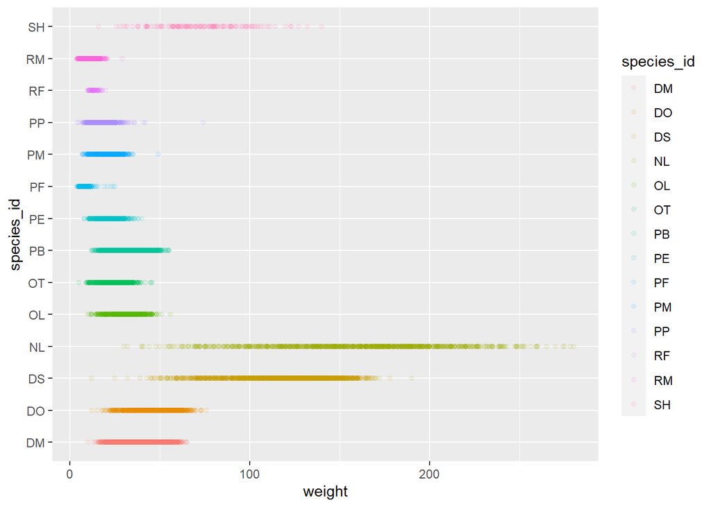

```
## [1] "This is not a good way to show this type of data because it does not show, mean, standard erros/ deviations of the data set. Therefore different species weights cannot be statistically compared"
```

```r
ggplot(data =surveys_complete, aes(x = weight,y =species_id))+
geom_point(aes(color=species_id), alpha=0.1)
```

# Boxplot

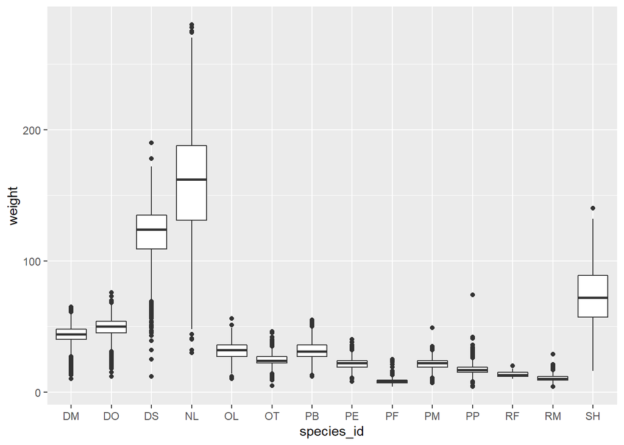

```r
ggplot(data=surveys_complete, mapping=aes(x=species_id, y= weight))+
  geom_boxplot()
```

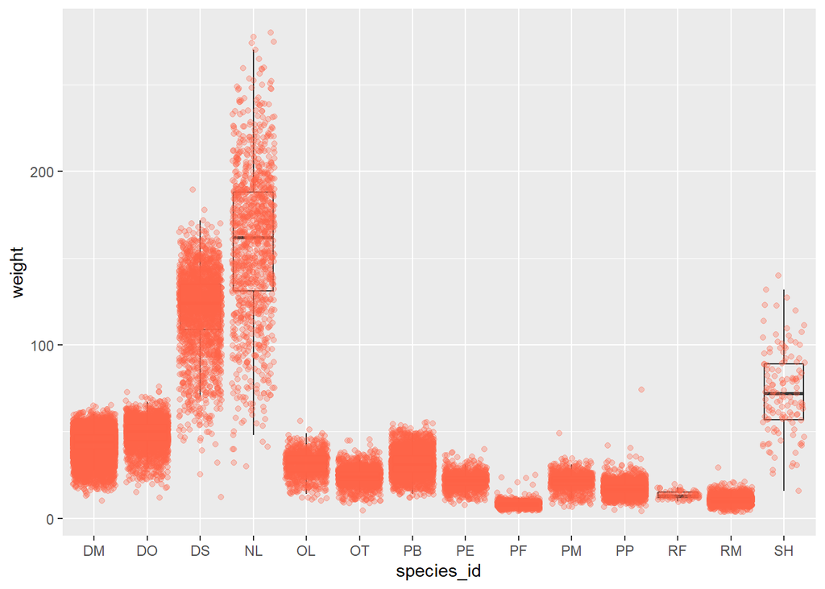

```r
ggplot(data=surveys_complete, mapping=aes(x=species_id, y= weight))+
  geom_boxplot(alpha=0)+
  geom_jitter(alpha=0.3, color= "tomato")
```

What do you need to change inthe code to put the boxplot in front of the points such that it’s not hidden?

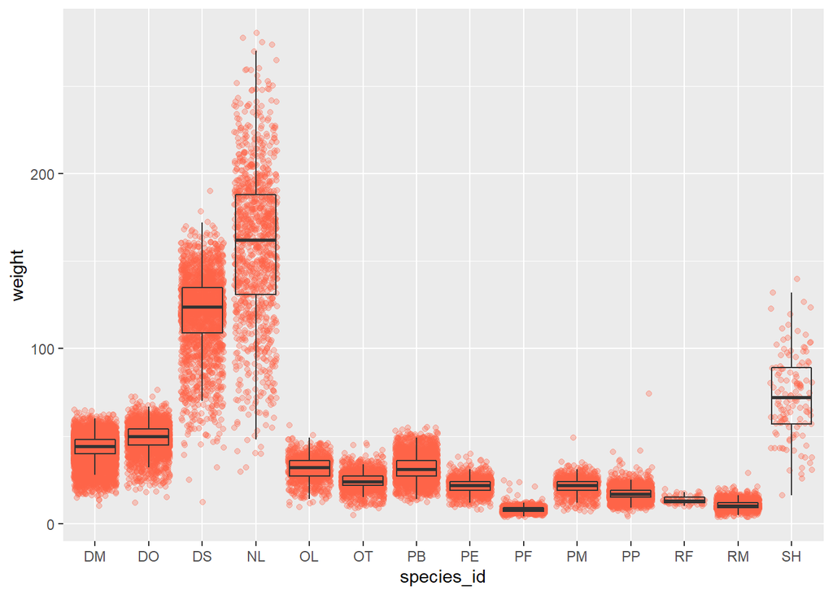

```r
ggplot(data=surveys_complete, mapping=aes(x=species_id, y= weight))+
  geom_jitter(alpha=0.3, color= "tomato")+
  geom_boxplot(alpha=0)
```

## **Challenges**

Replace the box plot with a violin plot; see geom_violin()

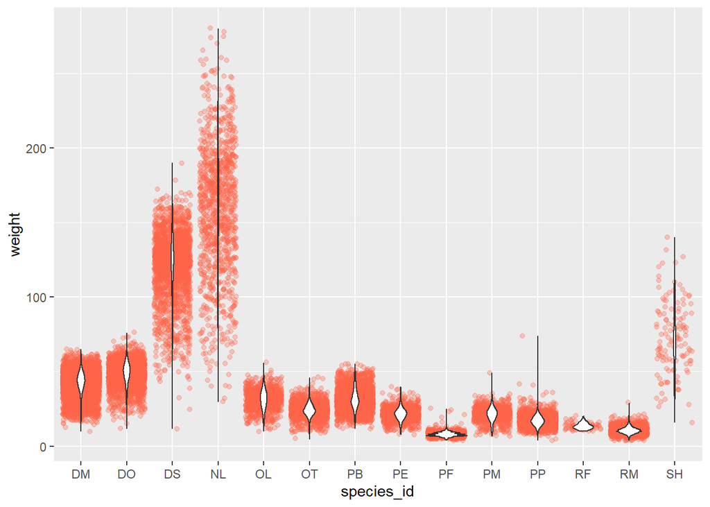

```r
ggplot(data=surveys_complete, mapping=aes(x=species_id, y= weight))+
  geom_jitter(alpha=0.3, color= "tomato")+
  geom_violin()
```

Represent weight on the logscale; see scale_y_log10()

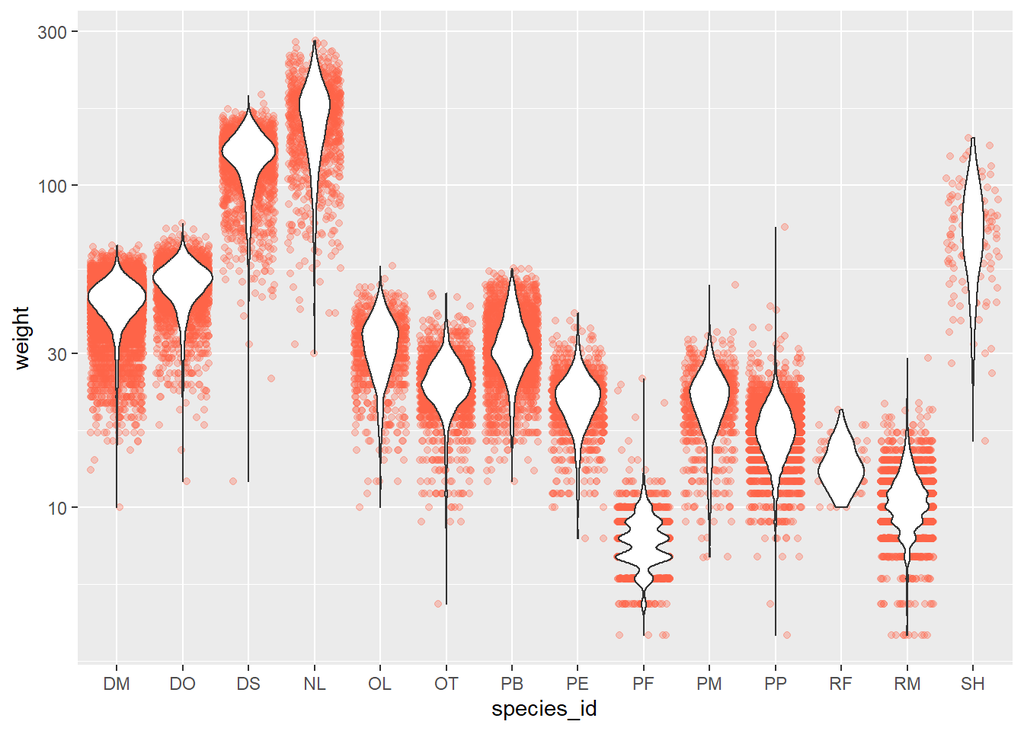

```r
ggplot(data=surveys_complete, mapping=aes(x=species_id, y= weight))+
  geom_jitter(alpha=0.3, color= "tomato")+
  geom_violin()+
  scale_y_log10()
```

Create boxplot for hindfoot_length. Overlay the boxplot layer on a jitter layer to show actual measurements

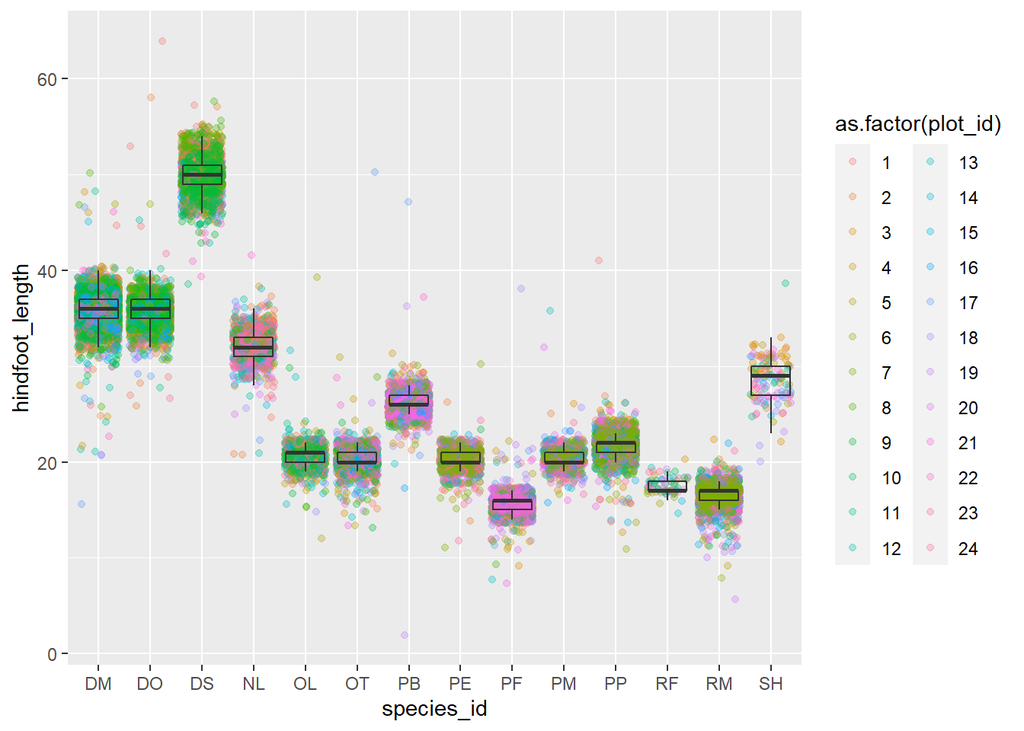

```r
ggplot(data=surveys_complete, mapping = aes(x= species_id, y=hindfoot_length))+
  geom_jitter( aes(color=as.factor(plot_id)), alpha=0.3)+
  geom_boxplot(alpha=0)
```

Hint: Check the class for plot_id . Consider changing the class of plot_id from integer to factor. Why does this change how R makes the graph?

```
## [1] "When plot_id is in the class numeric R assign colors to plot_id as a gradient. But When it is a factor each factor is colored as a distinct category"
```